# Chatbot

hyo

2020 5 11

# Telegram에서 챗봇 사용하기

#### 1.텔레그램 가입 후에 연락처에서 ‘BotFather’를 검색한다

[figure not shown]

#### 2. BotFather를 클릭하고 시작 버튼을 누른다.

[figure not shown]

#### 3. “/newbot”이라고 메세지를 보낸다.

- “/newbot”이라고 메세지는 보내면 Bot의 이름을 지정하라는 메시지가 보인다. Bot의 이름을 지정한다. (두번 작성해야함)
- Bot의 이름을 지정하면 username을 지정라하고 메세지가 뜬다. username을 지정할 때 반드시 ‘bot’으로 끝나는 username을 지정해야한다. username을 지정한다.

[figure not shown]

#### 4. ‘bot’으로 끝나는 username을 지정하고 나면 bot에 연결할 수 있는 token이 나온다.

- username과 token을 따로 기록한다.
- 이름 : hyo_test_bot
- 1114328444:AAGgG09h_cf3XDx0V7p5hXuka8G4a_4al7Q

[figure not shown]

#### 5. 텔레그램에서 채널을 만든다.

- 채널명을 지정한다.

[figure not shown]

#### 6. 채널 종류를 공개로 설정하고 “t.me/” 이후에 채널 링크를 지정한다.

- 지정된 링크가 사용가능한지 확인한다.
- 지정된 채널 링크는 기록한다.

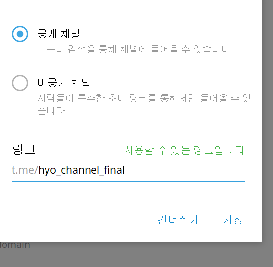

#### 7. 채널 페이지 오른쪽 위에서 채널관리 - 관리자 - 관리자 추가 의 순서를 통해 생성시킨Bot을 관리자로 추가시킨다. Bot를 추가할 때 username이 아닌 Bot 이름으로 검색한다

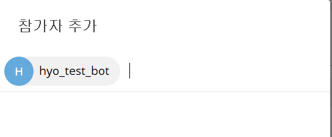

#### 8. 관리자 추가 설정을 해준다

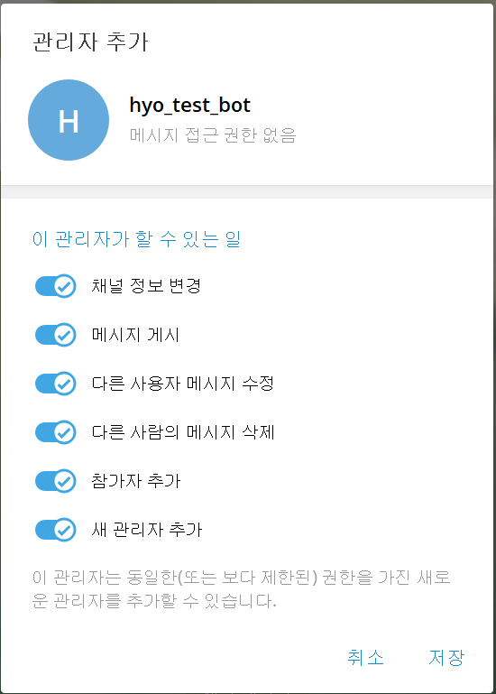

#### 9. hello를 입력하여 활성화시키기

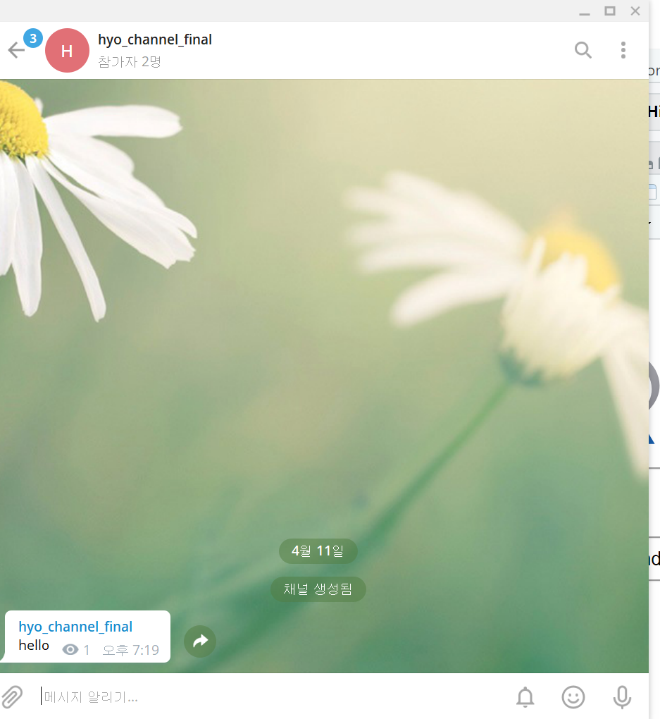

#### 10. `https://api.telegram.org/bot1114328444:AAGgG09h_cf3XDx0V7p5hXuka8G4a_4al7Q/getUpdates` 링크 확인하기

- bot에 연결할 수 있는 token: 1114328444:AAGgG09h_cf3XDx0V7p5hXuka8G4a_4al7Q

[figure not shown]

#### 11.R코드 입력

- bot = Bot(token =)으로 연결하기
- 위 링크에서 확인한 경로대로 입력하여 text를 보낸다 channel_post -> chat -> id

```r
if(!require(telegram.bot)){install.packages('telegram.bot');library(telegram.bot)}
bot = Bot(token = '1114328444:AAGgG09h_cf3XDx0V7p5hXuka8G4a_4al7Q')
print(bot$getMe())
```

```
## $id
## [1] 1114328444
##
## $is_bot
## [1] TRUE
##
## $first_name
## [1] "hyo_test_bot"
##
## $username
## [1] "hyo_test_bot"
##
## $can_join_groups
## [1] TRUE
##
## $can_read_all_group_messages
## [1] FALSE
##
## $supports_inline_queries
## [1] FALSE
```

```r
updates = bot$getUpdates()

#봇으로 보내는 id
updates[[1]]$message$chat$id
```

```
## [1] 1120008187
```

```r
#채널로 보내는 id
updates[[4]]$channel_post$chat$id
```

```
## [1] -1.00138e+12
```

```r
chat_id = updates[[1]]$message$chat$id
chat_id
```

```
## [1] 1120008187
```

```r
channel_id = updates[[4]]$channel_post$chat$id

bot$sendMessage(chat_id = updates[[1]]$message$chat$id, text = 'hello bot!')
bot$sendMessage(chat_id = channel_id, text = '>(채권) 신흥국과 원화 자산에 드리울 단기적
시련: 좋았던 약달라의 강세 되돌림이 나타나고 있음. 건강한 성장을 위해서는
불가피함')
```

#### 12. 결과

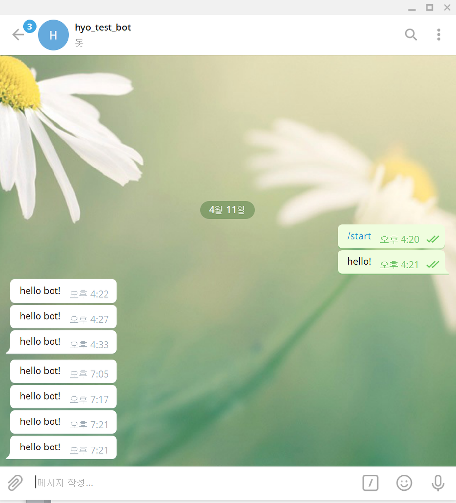